# Project 2- Vidhi Sapru

Vidhi Sapru

2022-11-09

# **Data Obtainment:**

In this report I will be using a dataset created by The University of Wisconsin-Madison. Specifically, this data was collected through a fine needle aspirate of breast mass and was then digitalized. Fine needle aspiratation is a type of biopsy done where a needle is inserted in the body where there seems to be something abnormal. The sample collected from the biopsy allows doctors to understand what is happening in the patients body, and possibly what is causing the abnormality. The dataset focuses on benign and malignant tumors, and specifically looks at the physical traits of the tumor. Some being, mean radius, perimeter, texture, and smoothness. I was easily able to obtain this dataset from an outside source- Kaggle. I was then able to download the dataset from Kaggle and read it into R by using the read.csv function. In this specific dataset there were no N/A values or other factors which would majorly impact the tidyness of the dataset. However, when uploading the dataset to R there was an extra column added,“X”, which did not have any values, but also did not impact the data. I was able to obtain and read in the data without any difficulties and did not have to make any changes to the dataset.

# **Purpose:**

I chose this dataset because I have been interested in cancer research and wanted to strengthen my understanding about breast cancer; specifically focusing on the tumors physical characteristics. Although, I have some previous knowledge about malignant and benign tumors, I wanted to look at the tumor itself and it’s features. Furthermore, the purpose of this report is to examine physical differences between malignant and benign tumors to further understand how they vary and how that impacts an individuals overall diagnosis. More specifically how their mean radius, perimeter, area, and other characteristics of the two tumor types differ.

# **Exploring Specific Variables**

In the “breastcancer” dataset I created, I chose to focus on the following variables the mean radius, mean perimeter, mean texture, mean area, and mean smoothness. In this dataset there are no missing values and I chose to specifically focus on the averages of the following variables listed below.

Breast Cancer Variables

| Variable Name | Description/Content | Variable Type |
| --- | --- | --- |
| Diagnosis | The diagnosis for the patient. M- Malignant and B- Benign | Categorical |
| radius_mean | Represents the mean radius of the tumor | Numeric |
| perimeter_mean | Represents the mean perimeter of the tumor | Numeric |
| texture_mean | Represents the mean texture of the tumor | Numeric |
| area_mean | Represents the mean area of the tumor | Numeric |
| smoothness_mean | Represents the mean smoothness of the tumor | Numeric |

# **Creating 3 New Variables**

Using a function, for loop, and “if else” statement, I was able to create a new variable where diagnoses with a radius above the average radius - for the entire dataset- were assigned either “TRUE” for being above the mean radius or “FALSE” for being below. For the other two variables I created, I used the mean function and created a new variable to assign either “TRUE” or “FALSE” to each diagnosis.

I chose to focus on which specific tumor types were above the average radius, perimeter, and area. When creating these variables I took the average of each individual column and created a function, such that if the value was above the average it would print “TRUE” and if the value was below “FALSE” would be printed in a new column. There were no missing values found in any of the variables.

New Breast Cancer Variables

[output not shown]

# **Univariate Graphs**

*As an important note, all the univarate graphs below are color coded so that blue represents malignant tumors and red represents benign tumors.*

The table below shows the number of benign and malignant diagnoses. I created this table using a for loop and the kable function. This table will later referenced to understand certain graphs.

Number of Malignant and Benign Tumors

| Diagnosis Type | Count |
| --- | --- |
| B | 357 |
| M | 212 |

In order to create all the univariate graphs, I created a function which would allow one to change the variable, color, title, and axis labels. I named the function “plot.univariate” and used it for each of the histogram graphs below.

The graph below explores how the mean radius of a malignant and benign tumor differ from one another. Based off of the graph majority of benign tumors radius are about 13, whereas for malignant tumors the distribution is spread evenly. Moreover, the counts for the benign tumor are much higher compared to the malignant tumor, this could be due to there being more data for benign tumors (357) and less for malignant (212). Taking a look at the means, the overall mean radius for maligant tumors is 17.4628302 which is higher than the mean for benign tumors, 12.1465238. Furthermore, malignant tumors seem to have a larger radius which means that the cancer cells are growing and possibly invading and destroying tissue in the body; also making it more harmful to an individual.

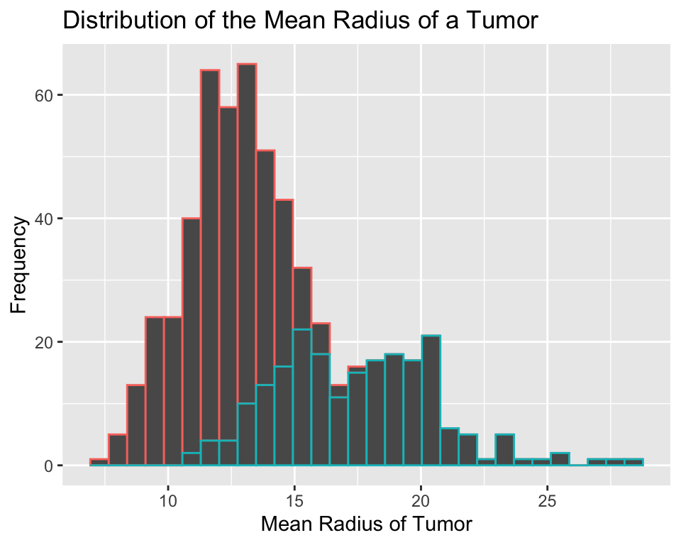

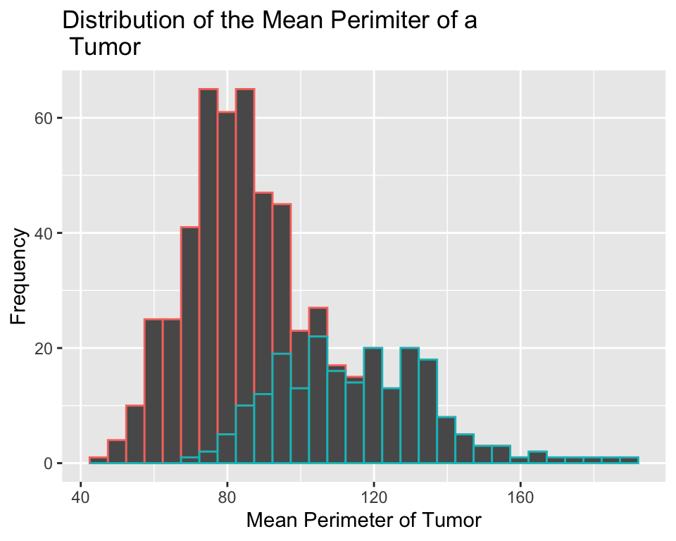

The graph below exhibits the mean texture of a tumor for malignant and benign tumors. To provide a little background about texture- mammographic texture helps researchers take another factor into account when looking at tumors and their physical characteristics to asses the level of danger. As shown in the graph, malignant tumors have higher texture values, again showing the dangers of having higher texture levels. However, in comparison to the previous graphs both tumor types overlap more and are closer in mean texture values. The overall mean texture for maligant tumors is 21.6049057 which is still higher than the mean for benign tumors, 17.9147619, but closer in value. This could be due texture not having as much of an impact on a cancer diagnosis.

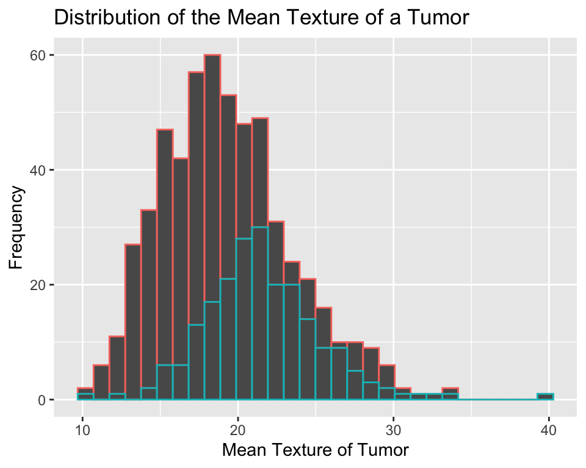

The graph below explores the mean area of a malignant and benign tumor. Compared to bengin tumors, malignant tumors seem to have a larger spread. Taking a look at the means, the overall mean area for maligant tumors is 978.3764151 which is higher than the mean for benign tumors, 462.7901961. Although, the area for malignant tumors is still overall larger, even with the larger spread. This could be because the tumor could still be “developing” and growing at a different rate. It is also unknown when each diagnosis was recorded and at what stage of cancer these results were recorded.

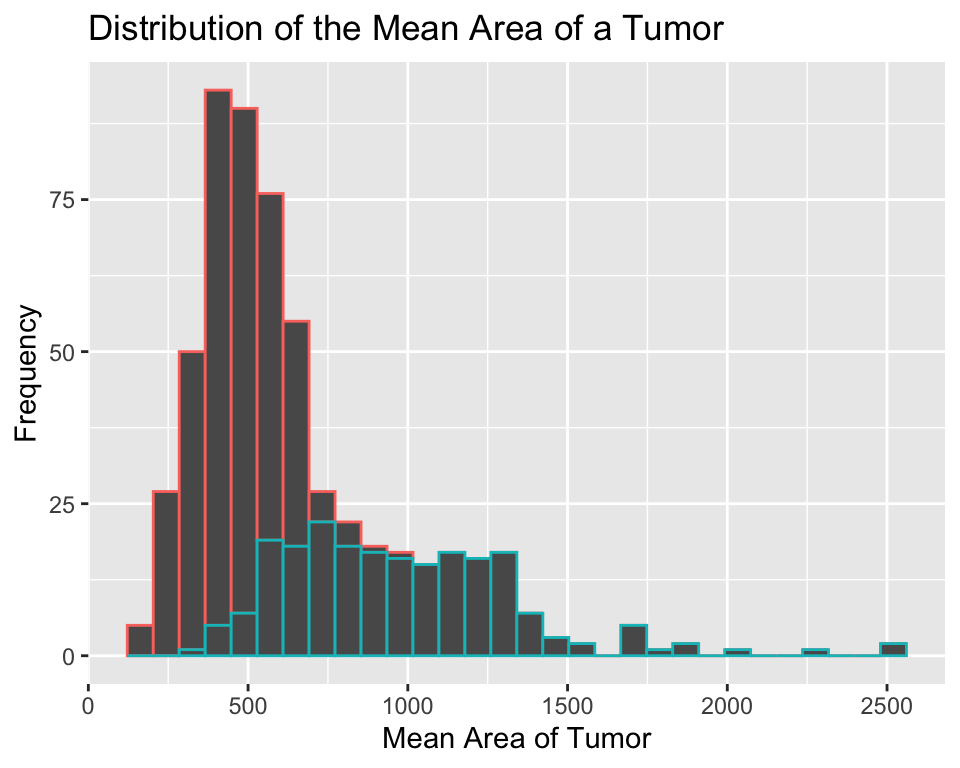

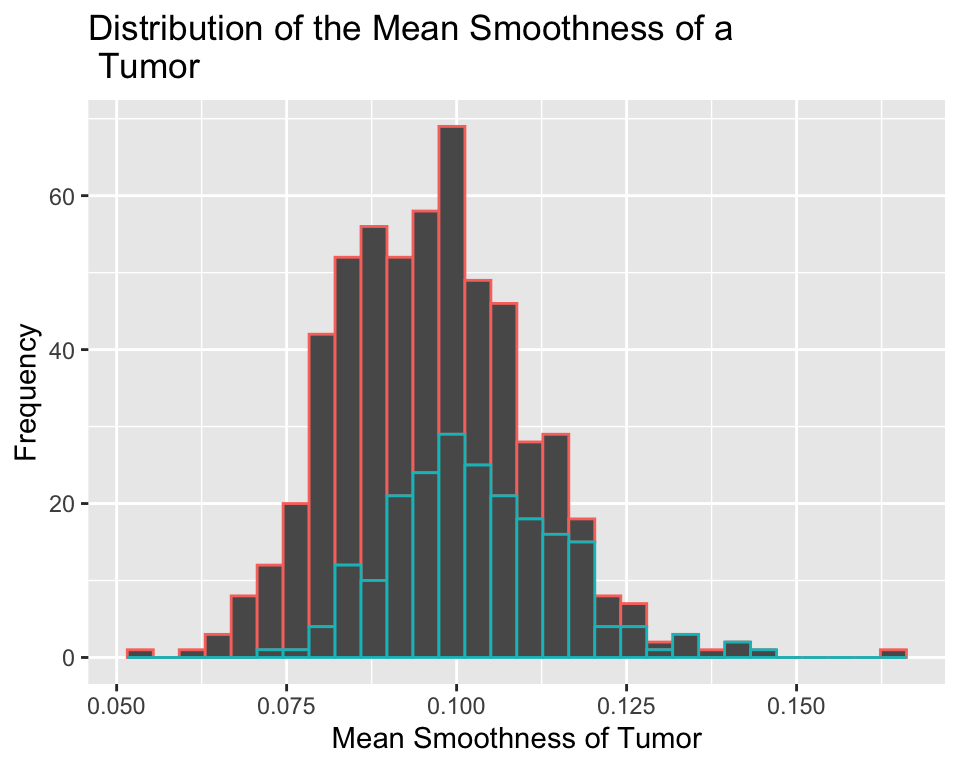

# **Multivariate Plots**

*It is important to note in the following multivariate graphs “B” stands for benign and “M” stands for malignant.*

In order to obtain the correlations for the two scatterplots below, I created a function “mean.cor” which would calculate the correlation and then print “The correlation is..”.

[figure not shown]

The scatterplot below examines the association between the mean radius and mean perimeter. The correlation is 0.9979. The correlation is positive and very close to one, which means that the mean radius and perimeter are positively associated however this does not imply causation. Moreover, looking at the differences between malignant and benign tumors, malignant tumors seem to have a larger spread of values and tend to be greater than the mean for the radius and perimeter. However, there are values for malignant tumors which overlap the benign tumors, which could be due to the stage of cancer the data was recorded at.

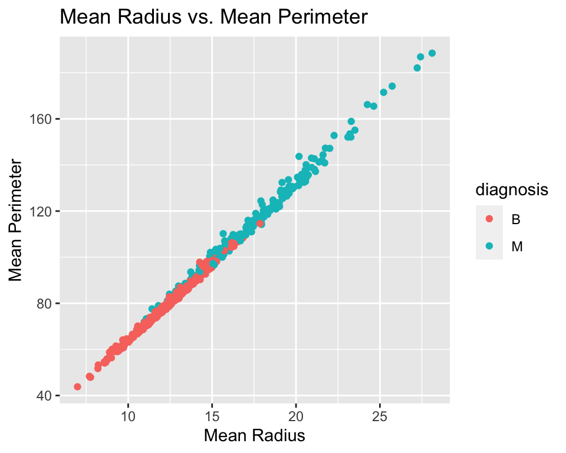

The scatterplot below explores the distribution between the mean radius and mean area of both tumors. The correlation is 0.9874.The correlation is positive and is almost one, which means that the mean radius and area are positively associated however this does not imply causation. Moreover, looking at the differences between malignant and benign tumors, malignant tumors seem to have a larger spread of values and tend to be greater than the mean for the radius and area. However, compared to the previous graph there is a smaller overlap between the tumor types.

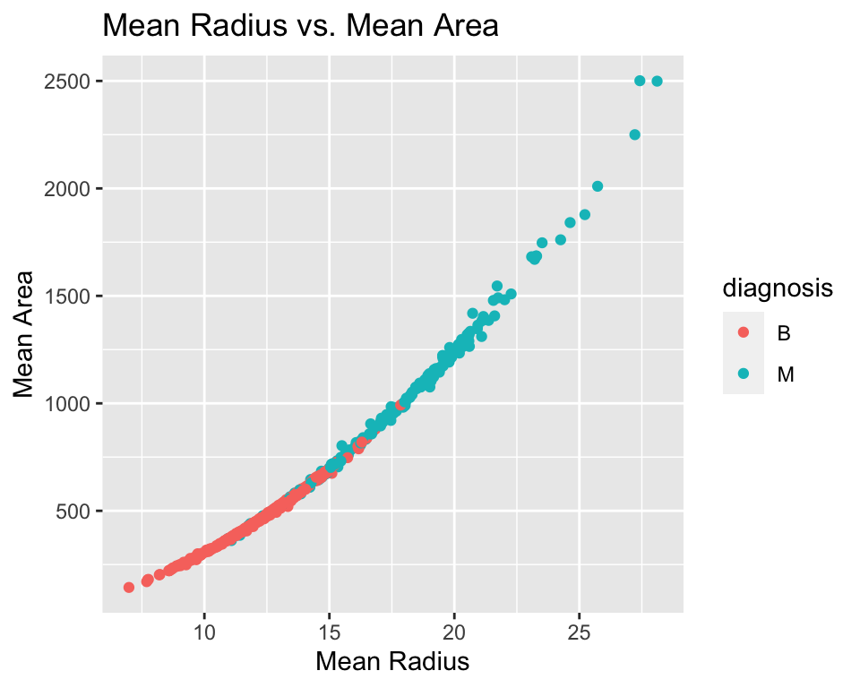

The boxplot below shows the distribtion of the mean area for both tumor types. From this boxplot it is shown that both tumor types have outliers which could possibly skew the data so that the average is higher or lower. Additionally, the pattern of malignant tumors having a higher area continues, in this plot we are able to see that the median for malignant tumors is significantly higher compared to the distribution of benign tumors.

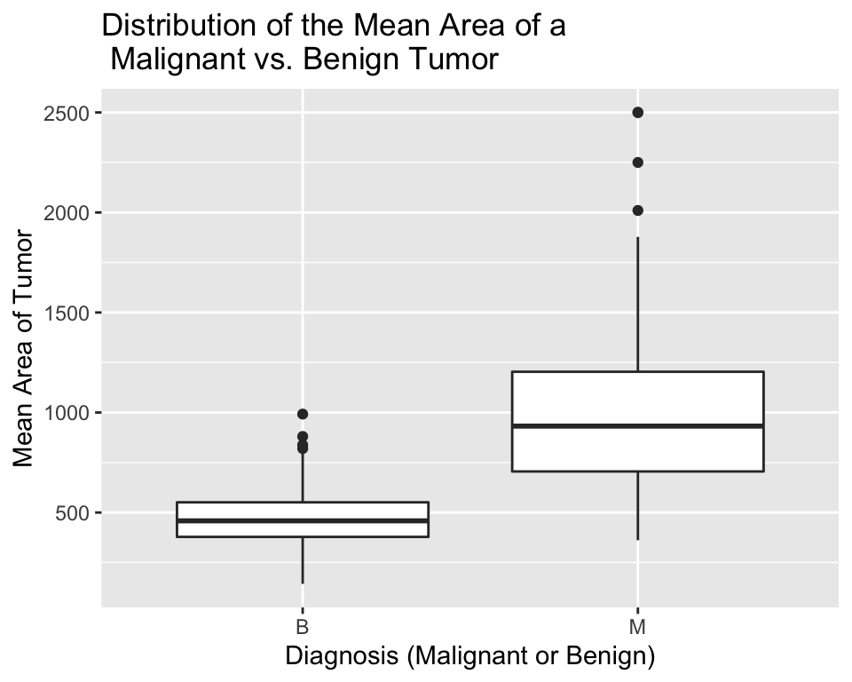

The figure below, explores the distribution of the mean perimeter for both diagnoses. From this boxplot it is shown that both tumor types have outliers which could possibly skew the data so that the average is higher or lower. Additionally, the pattern of malignant tumors having a higher perimeter continues, in this plot we are able to see that the median for malignant tumors is significantly higher compared to the distribution of benign tumors.

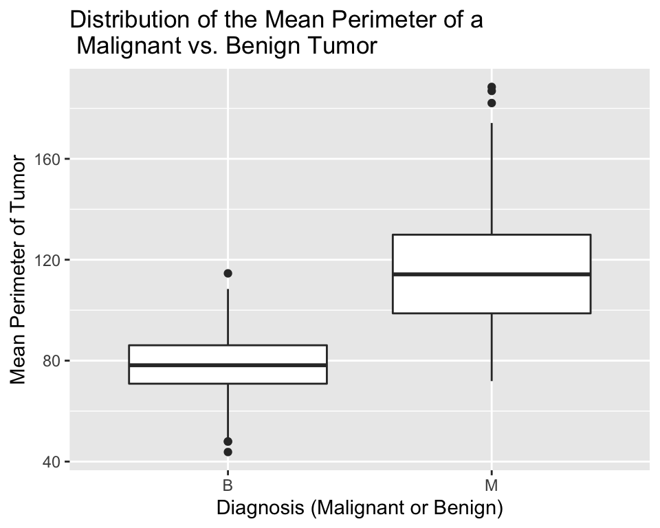

# **Conclusion**

In this report, I did not have any N/A values when creating new variables or in the original dataset. Throughout this report, I faced a few problems where I needed to debug my code. For example, there were a few instances where I forgot a comma or parenthesis and I had to go back and check each line to see why the r chunk did not run. Another issue I faced was when looking at my inline code, when I knit the rmarkdown file it would not show up. I then tried the inline code with cor instead of my mean.cor function and the code showed up when I knit the file. I realized that there was something wrong in my mean.cor function, and tried changing print to return. Afterwards, I knit the rmarkdown file again, and the incline code appeared. Another example, of my debugging experience was working with my ggplot function. I wanted my univariate graphs to have two colors to show the different distributions for the malignant and benign tumors. I initially had it so that color.want equaled diagnosis, however that did not run. I tried to set the color.want equal to blue, and then when I used the function set color.want to diagnosis, however my code did not run. I then tried leaving color.want and not assigning it to anything, by doing this I was able to set color.want equal to diagnosis and my function successfully ran.

Github Repository Link: https://github.com/vidhisapru/Project-2-SDS-

# **References**

1. Chitalia RD, Kontos D. Role of texture analysis in breast MRI as a cancer biomarker: A review. J Magn Reson Imaging. 2019 Apr;49(4):927-938. doi: 10.1002/jmri.26556. Epub 2018 Nov 3. PMID: 30390383; PMCID: PMC7077754. https://www.ncbi.nlm.nih.gov/pmc/articles/PMC7077754/
2. Matthew Hoffman, MD Fine Needle Aspirattion https://www.webmd.com/a-to-z-guides/fine-needle-aspiration
3. Fine Needle Aspiration (FNA) of the Breast https://www.cancer.org/cancer/breast-cancer/screening-tests-and-early-detection/breast-biopsy/fine-needle-aspiration-biopsy-of-the-breast.html